## Predicting Exercise Quality With Machine Learning

Author: Daniela Petruzalek  
e-mail: daniela.petruzalek@gmail.com  
Date : June 24, 2016

### Introduction

This is the final project for the Practical Machine Learning course from John Hopkins University School of Public Health on Coursera.

### Executive Summary

One thing that people regularly do is quantify how much of a particular activity they do, but they rarely quantify how well they do it. In this project, the goal is to use data[^1] from accelerometers on the belt, forearm, arm, and dumbell of 6 participants to predict if an exercise is correctly performed or not.

Six young health participants were asked to perform one set of 10 repetitions of the Unilateral Dumbbell Biceps Curl in five different fashions: exactly according to the specification (Class A), throwing the elbows to the front (Class B), lifting the dumbbell only halfway (Class C), lowering the dumbbell only halfway (Class D) and throwing the hips to the front (Class E).

This project will utilize machine learning techniques to predict which class of exercise fits best the given test dataset, composed by 20 observations.

### Exploratory Analysis

We’ll start by downloading the datasets and running some exploratory analysis.

```r
train.data.url  <- "https://d396qusza40orc.cloudfront.net/predmachlearn/pml-training.csv";
test.data.url   <- "https://d396qusza40orc.cloudfront.net/predmachlearn/pml-testing.csv"

train.data.file <- "pml-training.csv"
test.data.file  <- "pml-testing.csv"

if(!file.exists(train.data.file))
        download.file(train.data.url, destfile = train.data.file)
if(!file.exists(test.data.file))
        download.file(test.data.url,  destfile = test.data.file)

# Weight Lifting Exercise dataset
wle     <- read.csv(train.data.file)
testing <- read.csv(test.data.file)

d <- dim(wle)
```

We have 19622 observations of 160 variables in the Weight Lifting Exercise (WLE) dataset. We will split this dataset into `training` and `validate` and then proceed with the exploratory analysis.

```r
set.seed(7777) # all lucky sevens! FF7 :)

idxTrain <- createDataPartition(wle$classe, p=0.75, list=FALSE)
training <- wle[idxTrain,]
validate <- wle[-idxTrain,]

# Save outcomes
train.classe <- wle[idxTrain, "classe"]
valid.classe <- wle[-idxTrain, "classe"]

dt1 <- dim(training); print(dt1)
```

```
## [1] 14718   160
```

```r
dt2 <- dim(validate); print(dt2)
```

```
## [1] 4904  160
```

```r
summary(training[,1:8])
```

```
##        X            user_name    raw_timestamp_part_1 raw_timestamp_part_2
##  Min.   :    1   adelmo  :2943   Min.   :1.322e+09    Min.   :   294
##  1st Qu.: 4907   carlitos:2333   1st Qu.:1.323e+09    1st Qu.:252294
##  Median : 9822   charles :2638   Median :1.323e+09    Median :496280
##  Mean   : 9812   eurico  :2289   Mean   :1.323e+09    Mean   :499311
##  3rd Qu.:14728   jeremy  :2547   3rd Qu.:1.323e+09    3rd Qu.:748405
##  Max.   :19622   pedro   :1968   Max.   :1.323e+09    Max.   :998801
##
##           cvtd_timestamp new_window    num_window    roll_belt
##  05/12/2011 11:24:1122   no :14422   Min.   :  1   Min.   :-28.90
##  28/11/2011 14:14:1105   yes:  296   1st Qu.:221   1st Qu.:  1.10
##  05/12/2011 11:25:1074               Median :425   Median :114.00
##  30/11/2011 17:11:1069               Mean   :431   Mean   : 64.62
##  02/12/2011 13:34:1052               3rd Qu.:645   3rd Qu.:123.00
##  02/12/2011 14:58:1041               Max.   :864   Max.   :162.00
##  (Other)         :8255
```

```r
str(training[,9:16])
```

```
## 'data.frame':    14718 obs. of  8 variables:
##  $ pitch_belt          : num  8.07 8.07 8.07 8.05 8.09 8.16 8.17 8.18 8.18 8.2 ...
##  $ yaw_belt            : num  -94.4 -94.4 -94.4 -94.4 -94.4 -94.4 -94.4 -94.4 -94.4 -94.4 ...
##  $ total_accel_belt    : int  3 3 3 3 3 3 3 3 3 3 ...
##  $ kurtosis_roll_belt  : Factor w/ 397 levels "","0.000673",..: 1 1 1 1 1 1 1 1 1 1 ...
##  $ kurtosis_picth_belt : Factor w/ 317 levels "","0.006078",..: 1 1 1 1 1 1 1 1 1 1 ...
##  $ kurtosis_yaw_belt   : Factor w/ 2 levels "","#DIV/0!": 1 1 1 1 1 1 1 1 1 1 ...
##  $ skewness_roll_belt  : Factor w/ 395 levels "","0.000000",..: 1 1 1 1 1 1 1 1 1 1 ...
##  $ skewness_roll_belt.1: Factor w/ 338 levels "","0.000000",..: 1 1 1 1 1 1 1 1 1 1 ...
```

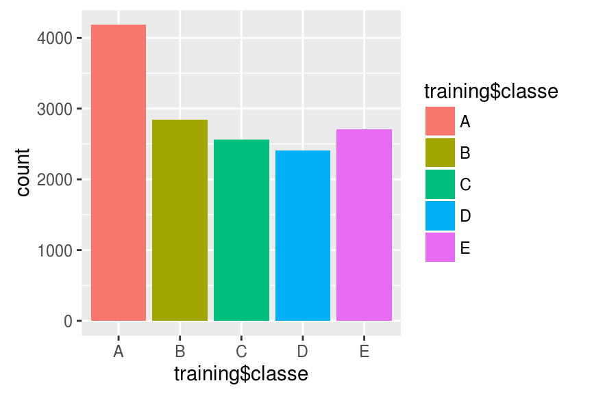

```r
qplot(training$classe, fill = training$classe)
```

The first seven columns will be removed from the model, since they are not features of the exercise, but the name of the subjects and the timestamp of the measures. Also, the final column will be removed as well, since it is the outcome `classe`. This will allow us to focus on the movement features for training our model.

A close inspection of the variables shows that several of the mesurements were loaded as factors, where they should have been loaded as numeric values. The code below accomplishes both tasks:

```r
training <- as.data.frame(apply(training[,-c(1:7, 160)], 2, as.numeric))
validate <- as.data.frame(apply(validate[,-c(1:7, 160)], 2, as.numeric))
```

When accounting for missing values, we can see that a great number of columns have mostly missing data (over 95% of the measurements):

```r
missing <- filter(data.frame(col.name = names(training),
                             miss.pct = round(apply(is.na(training), 2, sum) / dt1[1], 2) ),
                  miss.pct > .95)
head(missing)
```

```
##               col.name miss.pct
## 1   kurtosis_roll_belt     0.98
## 2  kurtosis_picth_belt     0.98
## 3    kurtosis_yaw_belt     1.00
## 4   skewness_roll_belt     0.98
## 5 skewness_roll_belt.1     0.98
## 6    skewness_yaw_belt     1.00
```

There are 100 columns that fit this criteria. Since those columns have little to contribute to our prediction, we will exclude them from our modeling.

```r
train  <- dplyr::select(training, which(round(apply(is.na(training), 2, sum ) / dt1[1], 2) < .95) )
d2     <- dim(train)

 # Final check for zero and near zero covariates among the remaining variables
nearZeroVar(train)
```

```
## integer(0)
```

After excluding the mostly empty columns and checking for zero and near zero covariates, we are left with 14718 observations of 52 variables to build our model.

### Model Training

Now that we have the most significant variables selected, we will setup the parallel processing libraries using the method described by Greski[^2]. This will allow faster processing times on multi-core CPUs.

We will also be employing a 5-fold cross-validation to the models to improve accuracy and reduce the bias.

```r
cluster <- makeCluster(detectCores()) # I'm running in a VM so I'm using all cores
registerDoParallel(cluster)

fitControl <- trainControl(method = "cv",
                           number = 5,
                           allowParallel = TRUE)
```

Next, we will fit three different models to check which one is more accurate for this dataset: random forest (rf), boosting with trees (gbm) and linear discriminant analysis (lda).

```r
model1 <- train(train.classe ~ ., method = "rf",  data = train, trControl = fitControl, verbose = FALSE)
model2 <- train(train.classe ~ ., method = "gbm", data = train, trControl = fitControl, verbose = FALSE)
model3 <- train(train.classe ~ ., method = "lda", data = train, trControl = fitControl, verbose = FALSE)

stopCluster(cluster) # close parallel cluster
```

The code below will run the predictions for the `validate` dataset using the models built above and plot the confusion matrices showing the accuracies for each model.

```r
p1 <- predict(model1, validate)
p2 <- predict(model2, validate)
p3 <- predict(model3, validate)

confusionMatrix(p1, valid.classe)
```

```
## Confusion Matrix and Statistics
##
##           Reference
## Prediction    A    B    C    D    E
##          A 1395    4    0    0    0
##          B    0  944    4    0    0
##          C    0    1  850   13    1
##          D    0    0    1  791    1
##          E    0    0    0    0  899
##
## Overall Statistics
##
##                Accuracy : 0.9949
##                  95% CI : (0.9925, 0.9967)
##     No Information Rate : 0.2845
##     P-Value [Acc > NIR] : < 2.2e-16
##
##                   Kappa : 0.9936
##  Mcnemar's Test P-Value : NA
##
## Statistics by Class:
##
##                      Class: A Class: B Class: C Class: D Class: E
## Sensitivity            1.0000   0.9947   0.9942   0.9838   0.9978
## Specificity            0.9989   0.9990   0.9963   0.9995   1.0000
## Pos Pred Value         0.9971   0.9958   0.9827   0.9975   1.0000
## Neg Pred Value         1.0000   0.9987   0.9988   0.9968   0.9995
## Prevalence             0.2845   0.1935   0.1743   0.1639   0.1837
## Detection Rate         0.2845   0.1925   0.1733   0.1613   0.1833
## Detection Prevalence   0.2853   0.1933   0.1764   0.1617   0.1833
## Balanced Accuracy      0.9994   0.9969   0.9952   0.9917   0.9989
```

```r
confusionMatrix(p2, valid.classe)
```

```
## Confusion Matrix and Statistics
##
##           Reference
## Prediction    A    B    C    D    E
##          A 1374   37    0    0    3
##          B   13  885   20    3   11
##          C    5   22  825   29    6
##          D    2    5   10  767   12
##          E    1    0    0    5  869
##
## Overall Statistics
##
##                Accuracy : 0.9625
##                  95% CI : (0.9568, 0.9676)
##     No Information Rate : 0.2845
##     P-Value [Acc > NIR] : < 2.2e-16
##
##                   Kappa : 0.9525
##  Mcnemar's Test P-Value : 3.659e-07
##
## Statistics by Class:
##
##                      Class: A Class: B Class: C Class: D Class: E
## Sensitivity            0.9849   0.9326   0.9649   0.9540   0.9645
## Specificity            0.9886   0.9881   0.9847   0.9929   0.9985
## Pos Pred Value         0.9717   0.9496   0.9301   0.9636   0.9931
## Neg Pred Value         0.9940   0.9839   0.9925   0.9910   0.9921
## Prevalence             0.2845   0.1935   0.1743   0.1639   0.1837
## Detection Rate         0.2802   0.1805   0.1682   0.1564   0.1772
## Detection Prevalence   0.2883   0.1900   0.1809   0.1623   0.1784
## Balanced Accuracy      0.9868   0.9603   0.9748   0.9735   0.9815
```

```r
confusionMatrix(p3, valid.classe)
```

```
## Confusion Matrix and Statistics
##
##           Reference
## Prediction    A    B    C    D    E
##          A 1145  156   86   47   29
##          B   28  597   72   38  165
##          C  120  126  562   95   81
##          D   97   28  118  604   90
##          E    5   42   17   20  536
##
## Overall Statistics
##
##                Accuracy : 0.7023
##                  95% CI : (0.6893, 0.7151)
##     No Information Rate : 0.2845
##     P-Value [Acc > NIR] : < 2.2e-16
##
##                   Kappa : 0.6232
##  Mcnemar's Test P-Value : < 2.2e-16
##
## Statistics by Class:
##
##                      Class: A Class: B Class: C Class: D Class: E
## Sensitivity            0.8208   0.6291   0.6573   0.7512   0.5949
## Specificity            0.9094   0.9234   0.8958   0.9188   0.9790
## Pos Pred Value         0.7826   0.6633   0.5711   0.6446   0.8645
## Neg Pred Value         0.9273   0.9121   0.9253   0.9496   0.9148
## Prevalence             0.2845   0.1935   0.1743   0.1639   0.1837
## Detection Rate         0.2335   0.1217   0.1146   0.1232   0.1093
## Detection Prevalence   0.2983   0.1835   0.2007   0.1911   0.1264
## Balanced Accuracy      0.8651   0.7762   0.7765   0.8350   0.7870
```

The random forest (`rf`) model outperform both the `gbm` and `lda` models with over 99% of accuracy against aproximately 96% and 70% respectively.

### Predicting the Testing Set

The final step is to predict the `testing` dataset composed by 20 observations, as proposed by the project’s especification. We will use the random forest model, since it has the better accuracy.

```r
testing  <- as.data.frame(apply(testing[,-c(1:7)],  2, as.numeric))
pred <- predict(model1, testing)
pred
```

```
##  [1] B A B A A E D B A A B C B A E E A B B B
## Levels: A B C D E
```

### Conclusions

For this particular exercise, the random forest model (`rf`) outperformed both the boosting with trees (`gbm`) and linear discriminant analysis (`lda`) models. Nevertheless, the `gbm` model performed close to the random forest, suggesting that it could also be applicable to a real world scenario, or maybe a combination (ensemble) of both. Further study on a different dataset is recommended.

### References

1. Velloso, E.; Bulling, A.; Gellersen, H.; Ugulino, W.; Fuks, H. Qualitative Activity Recognition of Weight Lifting Exercises. Proceedings of 4th International Conference in Cooperation with SIGCHI (Augmented Human ’13) . Stuttgart, Germany: ACM SIGCHI, 2013.
2. Greski, L. Improving Performance of Random Forest in caret::train(). Available on [GitHub](https://github.com/lgreski/datasciencectacontent/blob/master/markdown/pml-randomForestPerformance.md). Acessed in June, 24 of 2016.
[^1]: 1
[^2]: 2